# Exploring the BRFSS data - UmaSekaran

## Setup

### Load packages

```r
library(ggplot2)
library(dplyr)
```

### Load data

```r
load("brfss2013.RData")
```

## Part 1: Data

The Behavioral Risk Factor Surveillance System (BRFSS) is an ongoing surveillance system designed to measure behavioral risk factors for the non-institutionalized adult population (18 years of age and older) residing in 50 states of US.

BRFSS does a prospective data analysis, where data collection is an ongoing activity.

But for our project, we are going to analyse the 2013 data,observed by BRFSS, which is past data. So, it is a restrospective observation/study.

In this survey, interviewers collect data from a randomly selected adult(18 years and above) in a US household (any of the 50 states), who resides in a private residence or college housing, who owns a landline or cellular telephone. So, there is random sampling.

These data can be analysed to establish associations between explanatory and response variables, to arrive at correlation statements.

This is a survey based on observations, not experimental data to derive causations.

So, this observational study can only be used to make generalized statements, not causation statements.

About the data:

```r
nrow(brfss2013)
```

```
## [1] 491775
```

```r
ncol(brfss2013)
```

```
## [1] 330
```

There are 491775 observations(rows) on 330 variables(columns) in the data set.

The dataset is supposed to contain 2013 data collected in the survey. Let us check

```r
brfss2013 %>%
  group_by (iyear) %>%
  summarise(count=n())
```

```
## # A tibble: 3 x 2
##    iyear  count
##   <fctr>  <int>
## 1   2013 486088
## 2   2014   5682
## 3     NA      5
```

The dataset has a small subset of 2014 and NA data,so let us filter them out.

```r
brfss2013fil <- brfss2013 %>% filter(iyear==2013)

brfss2013fil %>%
  group_by (iyear) %>%
  summarise(count=n())
```

```
## # A tibble: 1 x 2
##    iyear  count
##   <fctr>  <int>
## 1   2013 486088
```

Now the new dataset ‘brfss2013fil’ has only 2013 data. We can summarise the survey data count by month

```r
summary(brfss2013fil$imonth)
```

```
##   January  February     March     April       May      June      July
##     29674     41860     44315     42936     40418     37912     43667
##    August September   October  November  December
##     42301     38563     42272     41932     40238
```

We can create a simple plot of the number of surveys per month with the command

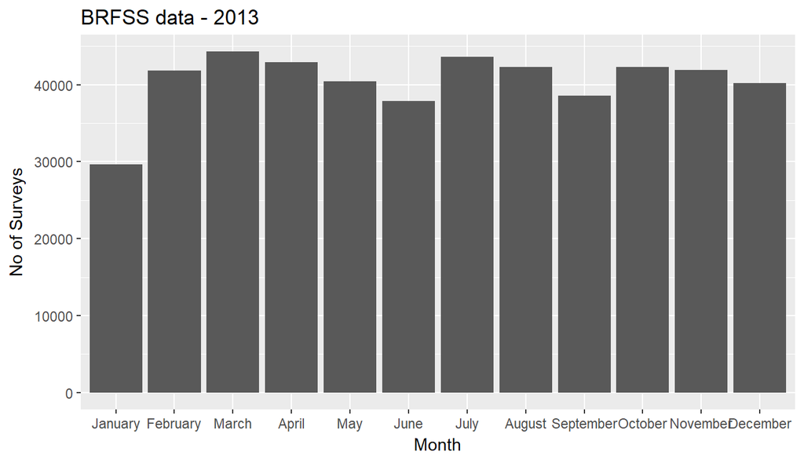

```r
ggplot(brfss2013fil, aes(imonth)) +
geom_bar(width =.9) +
ggtitle("BRFSS data - 2013") +
xlab("Month") +
ylab("No of Surveys")
```

* * *

## Part 2: Research questions

**Research question 1:**

Our first research question would be to identify which top 10 states in the US have the highest percentage of adults with excellent health condition among the total surveyed.

**Research question 2:**

The second research question is to identify the people with No healthplan and who could not see Doctor because of cost., which will in turn help to identify the states that need Health Plan.

**Research question 3:**

Among people with some exercise activity, identify the proportion of people who does ‘Walking’ as their exercise activity. * * *

## Part 3: Exploratory data analysis

**Research question 1:** Our first analysis is to find the top 10 states in the US with highest percentage of adults with excellent health condition among the total surveyed.

Affected variables: X_state : State Fips Code genhlth : General Health

Let us start with identifying the total number of surveys per state(‘total_surveyed_statewise’). A dataset ‘brfss2013_total_statewise’ is created as the summarised table of people surveyed in each state of US. We would be using the variable ‘X_state’ to summarise the count of people surveyed. Also the summarised data is sorted in descending order.

```r
brfss2013_total_statewise <- brfss2013fil %>%
  group_by(X_state) %>%
  summarise(total_surveyed_statewise=n()) %>%
  arrange(desc(total_surveyed_statewise))
```

To identify the count of people with ‘Excellent’ general health, ‘genhlth’ variable is used to filter the dataset. Then it is summarised state-wise and genhlth-wise, so that we get the statewise count of people with Excellent health condition, in a separate dataset ‘brfss2013_exclhlth_statewise’ Also the summarised data is sorted in descending order.

```r
brfss2013_exclhlth_statewise <- brfss2013fil %>%
  filter(genhlth=="Excellent")%>%
  group_by(X_state,genhlth) %>%
  summarise(exclhlth=n()) %>%
  arrange(desc(exclhlth))
```

To arrive at the percentage of people with Excellent health condition, we have to prepare a dataset that has both the total count of people and the total count of people with excellent health condition. So, we merge the above 2 datasets ‘brfss2013_exclhlth_statewise’ and ‘brfss2013_total_statewise’ using merge command and merging condition variable ‘X_state’.

```r
bfrss2013_exclhlth_prcnt <- merge(brfss2013_total_statewise,brfss2013_exclhlth_statewise,by="X_state")
```

This dataset ‘bfrss2013_exclhlth_prcnt’, contains the total count of people surveyed as well as the total count of people with excellent health condition. Divide both to get a new column variable ‘prcnt_exclhlth’ using ‘mutate’ command, which gives the percentage of people with excellent health condition in each state.

```r
bfrss2013_exclhlth_prcnt <- bfrss2013_exclhlth_prcnt %>%
mutate(prcnt_exclhlth = exclhlth / total_surveyed_statewise) %>%
arrange(desc(prcnt_exclhlth)) %>%
top_n(10,prcnt_exclhlth)
```

Plot the dataset ‘bfrss2013_exclhlth_prcnt’ in a bar plot with states(X_state variable) in x axis and percentages(prcnt_exclhlth) in y axis.

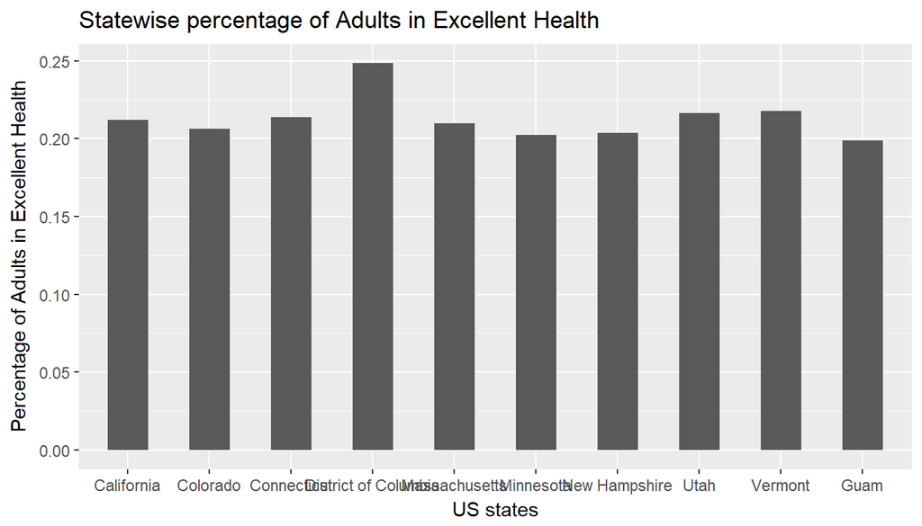

```r
ggplot(bfrss2013_exclhlth_prcnt, aes(x = X_state , y = prcnt_exclhlth)) +
geom_bar(stat = "identity",width = .5) +
ggtitle("Statewise percentage of Adults in Excellent Health") +
xlab("US states") +
ylab("Percentage of Adults in Excellent Health")
```

**Research question 2:** For the second analysis,we have to identify the people with No healthplan and who could not see Doctor because of cost., which will in turn help to identify the states that need Health Plan.

For this, we shall start with the dataset ‘brfss2013fil’ that has only 2013 data. Affected variables: hlthpln1 : Have Any Health Care Coverage medcost : Could Not See Dr. Because Of Cost

Let us clean up the genhlth variable that has NA. Also apply the filters - hlthpln1 NO and medcost YES.

Group the data based on X_state, hlthpln1 and medcost and summarise the count of people, which gives state-wise count of people who don’t have Health Plan coverage, but could not see Doctor due to cost. Move the data into a new dataset ‘brfss2013_NeedHealthPlan’

```r
brfss2013_NeedHealthPlan <-brfss2013fil %>%
  filter(!is.na(genhlth),hlthpln1=="No",!is.na(medcost),medcost=="Yes")%>%
  group_by(X_state,hlthpln1,medcost) %>%
  summarise(Medcost_High=n()) %>%
  arrange(desc(Medcost_High)) %>%
  head(5)
```

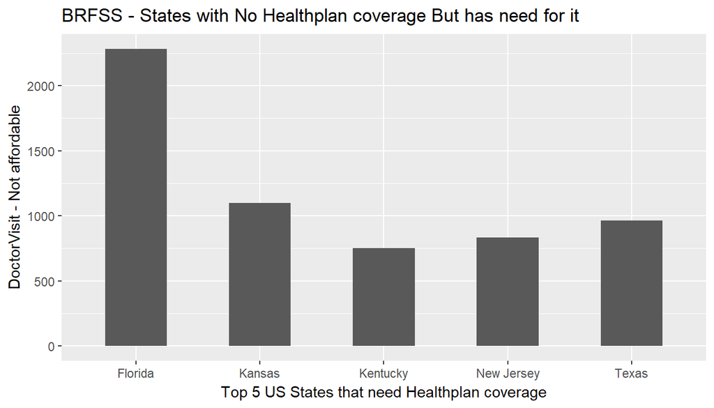

```r
ggplot(brfss2013_NeedHealthPlan, aes(x=X_state,y=Medcost_High)) +
geom_bar(stat = "identity",width = .5) +
ggtitle("BRFSS - States with No Healthplan coverage But has need for it") +
xlab("Top 5 US States that need Healthplan coverage") +
ylab("DoctorVisit - Not affordable")
```

Before we start our analysis, let us study the summarised data based on the ‘X_bmi5cat’ variable, that classifies people as Underweight/Normal/Overweight/Obese. There are data with NA values, that needs to be removed.

```r
brfss2013fil %>%
  group_by(X_bmi5cat) %>%
  summarise(count=n())
```

```
## # A tibble: 5 x 2
##       X_bmi5cat  count
##          <fctr>  <int>
## 1   Underweight   8156
## 2 Normal weight 153057
## 3    Overweight 165210
## 4         Obese 133291
## 5            NA  26374
```

```r
brfss2013_anyexercise <- brfss2013fil %>%
  filter(!is.na(X_bmi5cat),!is.na(exerany2),exerany2=="Yes") %>%
  group_by(X_bmi5cat,exerany2) %>%
  summarise(exerany2count=n()) %>%
  arrange(desc(exerany2count)) %>%
  top_n(5,exerany2count)
```

To drill down the dataset further, create another dataset ‘brfss2013_walkexercise’ that does ‘Walking’ as workout activity - filter out the data with ‘exerany2’ as Yes, group them by the X_bmi5cat and exract11 as ‘Walking’ and get the counts. This would give us the relative count of people who do ‘Walking’ as exercise activity.

```r
brfss2013_walkexercise <- brfss2013fil %>%
  filter(!is.na(X_bmi5cat),!is.na(exerany2),exerany2=="Yes",exract11== "Walking") %>%
  group_by(X_bmi5cat,exerany2) %>%
  summarise(walkcount=n()) %>%
  arrange(desc(walkcount)) %>%
  top_n(5,walkcount)
```

Merge these two datasets to arrive at another dataset ‘bfrss2013_Exerwalk_prcnt’ that contains both the summarised counts.

```r
bfrss2013_Exerwalk_prcnt <- merge(brfss2013_anyexercise,brfss2013_walkexercise,by="X_bmi5cat")
```

Plot the data as a bar chart

[figure not shown]

```r
ggplot(data=bfrss2013_Exerwalk_prcnt, aes(x=X_bmi5cat,y=exerany2count,fill=walkcount)) +
geom_bar(stat='identity') + xlab("BMI category") + ylab("Percentage of people who do Walking ")
```